# ToothGrowth Inferential Data Analysis

Charles Yoo

June 19, 2016

## Overview

This project investigages the correlation that various dosages and supplements have on tooth length using the ToothGrowth dataset. The null hypothesis is that OJ has a stronger efficacy on tooth growth than Vitamin C.

## Load Data

```r
data(ToothGrowth)
```

## Summary of Data

```r
# description of variables
str(ToothGrowth)
```

```
## 'data.frame':    60 obs. of  3 variables:
##  $ len : num  4.2 11.5 7.3 5.8 6.4 10 11.2 11.2 5.2 7 ...
##  $ supp: Factor w/ 2 levels "OJ","VC": 2 2 2 2 2 2 2 2 2 2 ...
##  $ dose: num  0.5 0.5 0.5 0.5 0.5 0.5 0.5 0.5 0.5 0.5 ...
```

```r
# summary of dataset
summary(ToothGrowth)
```

```
##       len        supp         dose
##  Min.   : 4.20   OJ:30   Min.   :0.500
##  1st Qu.:13.07   VC:30   1st Qu.:0.500
##  Median :19.25           Median :1.000
##  Mean   :18.81           Mean   :1.167
##  3rd Qu.:25.27           3rd Qu.:2.000
##  Max.   :33.90           Max.   :2.000
```

```r
# look at first 6 rows
head(ToothGrowth)
```

```
##    len supp dose
## 1  4.2   VC  0.5
## 2 11.5   VC  0.5
## 3  7.3   VC  0.5
## 4  5.8   VC  0.5
## 5  6.4   VC  0.5
## 6 10.0   VC  0.5
```

```r
# count number of rows
nrow(ToothGrowth)
```

```
## [1] 60
```

```r
dim(ToothGrowth)
```

```
## [1] 60  3
```

```r
# exploration of data
unique(ToothGrowth$dose)
```

```
## [1] 0.5 1.0 2.0
```

```r
unique(ToothGrowth$supp)
```

```
## [1] VC OJ
## Levels: OJ VC
```

```r
# table comparing dose to supp
table(ToothGrowth$dose, ToothGrowth$supp)
```

```
##
##       OJ VC
##   0.5 10 10
##   1   10 10
##   2   10 10
```

## Comparison of dose to supp

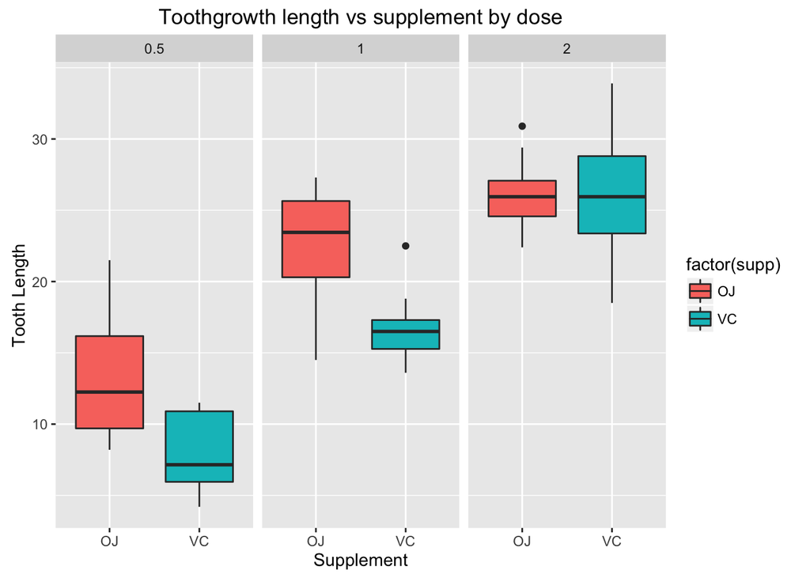

```r
ggplot(ToothGrowth, aes(x = supp, y = len)) +
        geom_boxplot(aes(fill = factor(supp))) +
        facet_grid(. ~ dose) +
        xlab("Supplement") +
        ylab("Tooth Length") +
        ggtitle("Toothgrowth length vs supplement by dose")
```

We see a visual correlation between dose size and tooth length. The higher the dosage of the supplement affects a longer tooth length. We also see that the type of supplement may have an effect on tooth length as well at the lower dosages.